# ccmar

- XLI CCM2022 Curso: Análisis y presentación de datos oceanográficos utilizando Júpyter y Matlab (ADJM).  
  **Claudio Iturra**, 2022  
  Departamento de Oceanografía, Universidad de Concepción, Concepción, Chile.  
  claudioiturra@oceanografia.udec.cl  
  https://claudioiturra.github.io

**Intro del Curso**

El curso ADJM introducirá el uso de la plataforma Jupyter Notebook mediante el análisis de datos oceanográficos. Jupyter Notebook es una gran herramienta para la programación interactiva. La plataforma permite combinar códigos, resultados de simulación, descripciones como comentarios y ecuaciones, manuscritos y presentaciones en un solo archivo de forma ordenada. La plataforma es compatible con variados lenguajes de programación (Matlab, Python, R, etc), el lenguaje que utilizaremos durante el curso sera Matlab. Este curso introductorio se basa en el primer segmento de los cursos Ocean/Atmosphere Time Series Analysis: Theory and Practice y Fundamentals of Ocean/Atmosphere Data Analysis, ambos dictados por The Alfred Wegener Institute.

El curso esta orientado para estudiantes de postgrado en Oceanografía (Ciencias del Mar), Ciencias Atmosféricas y Clima. El curso requiere que los participantes tengan nociones básicas del lenguaje de programación Matlab. Utilizando Jupyter Lab, el curso comenzara con una breve descripción de la plataforma mediante una clase interactiva de un tópico de interés (Ej; Series de Furier). Luego de conocer las características de la plataforma mediante variados ejemplos, trabajaremos analizando datos oceanográficos de satélites (temperatura, clorofila y viento), derivadores y perfiladores Argo (asociados al área de interés de los participantes). Los participantes podrán traer sus propias bases de datos, con el fin de generar una breve presentación utilizando la plataforma de trabajo y utilizando los datos analizados. La modalidad del curso será de dos secciones intensivas con una duración de un día de trabajo. Para participar del curso es necesario enviar un correo a claudioiturra@oceanografia.udec.cl, con tu nombre, programa de estudio, breve descripción de tu investigación (*incluir área de estudio*) y tu dirección de correo (Cupos Limitados). Una vez registrado en el curso te haré llegar un correo con información esencial de las actividades a realizar. El curso se dictara de forma presencial en el campus San Andrés de La Universidad Católica de la Santísima Concepción (UCSC).

Registration deadline: 15 May 2022

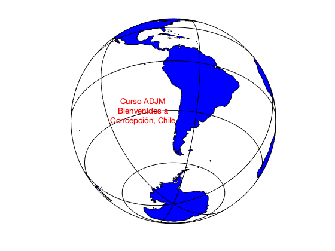

```matlab
m_proj('ortho','lat',-36','long',-75');
m_coast('patch','b');
m_grid('linest','-','xticklabels',[],'yticklabels',[]);
message = sprintf('Curso ADJM\nBienvenidos a\nConcepción, Chile');
text(-0.3,0.1,message,'fontsize',10,'color','r',...
    'verticalalignment','middle','horizontalalignment','center');
```

El Curso ADJM-004 es parte del Congreso de Ciencias del Mar 2022 organizado por La Universidad Católica de la Santísima Concepción (UCSC) y la Sociedad Chilena de Ciencias del Mar (SCHCM).

Participantes 2022/06 (*Last update 20220320*)

01) **Rosana Cárdenas Cartes** (Geofisica, Universidad de Concepción, Chile)  
roscardenas@udec.cl  
Investigación: Circulacion costera.  
Área de estudio: Océano costero de Chile.

02) **Reynier Bada Diaz** (Clima y oceanografía, Universidad de Concepción, Chile)  
rbada@udec.cl  
Investigación: A relationship between intraseasonal and synoptic atmospheric variability and high chlorophyll-a events in the Puyuhuapi Fjord, Chilean Patagonia.  
Área de estudio: Centro-Sur de Chile.

03) **Lenna Oriana Ortiz Castillo** (Oceanografía, Universidad de Concepción, Chile)  
lennaoriana@gmail.com  
Investigación: Remolinos de mesoescala e interacción de procesos físico-biogeoquímicos con el uso de modelos acoplados.  
Área de estudio: Pacífico Suroriental.

04) **Francesca Victoria** (Oceanografía, Universidad de Valparaíso, Chile)  
fran.search.t@gmail.com  
Investigación: Circulacion costera.  
Área de estudio: Bahía de Algarrobo.

05) **Cynthia Fuentes Quian** (Oceanografía, **Ecogestión ambiental**, Chile)  
cfuentes@ecogestionambiental.cl  
Investigación:  
Área de estudio:

06) **María José Brüning Belmar** (Biología Marina, Universidad Austral de Chile, Chile)  
maria.bruning@alumnos.uach.cl  
Investigación: Respuesta de larvas de jaibas a cambio extremos de temperatura (Experimental)  
Área de estudio: Océano costero de Chile

07) **Laura Gutiérrez Cabello** (Oceanografía, Universidad de Concepción, Chile)  
laura.11.gc@gmail.com  
Investigación:Presencia acústica de misticetos asociados a específicos patrones de temperatura y salinidad.  
Área de estudio: Patagonia Norte, entre la Isla Guafo y el Mar interior de Chiloé.

08) **Melissa Fernandez** (Biología Marina, Universidad Andrés Bello, **Bajamar Lab**, Chile)  
ignacia.fernandezg10@gmail.com  
Investigación: Evaluación del impacto del gradiente de surgencia en los servicios ecosistémicos costeros.  
Área de estudio: Costa de Chile continental

09) **Jorge Mauricio Oyanadel Castillo** (Biología Marina, Universidad Católica del Norte, **Laboratorio de Oceanografía**, Chile)  
jorge.oyanadel@alumnos.ucn.cl  
Investigación: Variabilidad de la circulación costera, su interacción con la batimetría y su efecto sobre la distribución de comunidades zooplanctónicas.  
Área de estudio: Área cercana a la isla Chañaral, al sur de la región de Atacama.

10) **Mayari Villalba** (Ciencia de datos, Universidad de Concepción, **Ecogestión ambiental**, Chile)  
mvillalba@ecogestionambiental.cl  
Investigación:  
Área de estudio:

11) **Gabriela Muñoz**** (Oceanografia, Universidad Católica de la Santísima Concepción, Chile)  
gabriela.luna.munoz@gmail.com  
Investigación: Evolución de tifones y huracanes en latitudes bajas.  
Área de estudio: Atlantico central.

12) **Linette Orozco Tralma**** (Ecología Marina, Universidad Católica de la Santísima Concepción, Chile)  
lorozco@magister.ucsc.cl  
Investigación:  
Área de estudio:

13) **Paula Amador Véliz**** (Laboratorio de Procesos Acoplados Biofísicos (LaPAB), Universidad Austral de Chile)  
pf.amadorveliz@gmail.com  
Investigación: Circulación y distribución de masas de agua Antárticas, Acoplamiento Biofísico.  
Área de estudio: Islas Shetland del Sur, Antártica.

14) **Jurleys Paola Vellojin Furnieles**** (Centro de Investigación Putemùn, Instituto de Fomento Pesquero)  
jurleys.vellojin@ifop.cl  
Investigación: Dinámica biogeoquímicas de la Patagonia Norte  
Área de estudio: Zona costera de Regiones de Los Lagos y de Aysén

15) **Iván Zurita Navarros**** (Universidad Austral de Chile )  
i.zurinava@alum.uca.es  
Investigación:  
Área de estudio:

Base de Datos

01) *roscardenas@udec.cl* [**Data01**](https://drive.google.com/drive/folders/1UfatB2utkBIISFg1n3VkWcGoEHMvTjro?usp=sharing)  
02) *rbada@udec.cl* [**Data02**](https://drive.google.com/drive/folders/1UYQiSofk2TcjBQk6nli8zGdMnZgp9956?usp=sharing)  
03) *lennaoriana@gmail.com* [**Data03**](https://drive.google.com/drive/folders/1UznEn_YVpJ5LVHpaAaN6UNwxVdwih0e8?usp=sharing)  
04) *fran.search.t@gmail.com* [**Data04**](https://drive.google.com/drive/folders/11JOf-I5GIKMMwomRLzdgNJNqaHZUgUzD?usp=sharing)  
05) *cfuentes@ecogestionambiental.cl* [**Data05**](https://drive.google.com/drive/folders/13dHON0TZ5rE7gYqta7YAIHOvkKNvVbOV?usp=sharing)  
06) *maria.bruning@alumnos.uach.cl* [**Data06**](https://drive.google.com/drive/folders/11HSBW2kPrOIok38yLXZhnx03no3gmQPZ?usp=sharing)  
07) *laura.11.gc@gmail.com* [**Data07**](https://drive.google.com/drive/folders/11JBgZSU3K1ecRpwu_tZ2je4SSjtGmibe?usp=sharing)  
08) *ignacia.fernandezg10@gmail.com* [**Data08**](https://drive.google.com/drive/folders/1Ug9S8pnjSAcGweRuU2Nih2G0OpWl926u?usp=sharing)  
09) *jorge.oyanadel@alumnos.ucn.cl* [**Data09**](https://drive.google.com/drive/folders/13oORtfcDH9MiQN5CkujsXlrQaB9koXPx?usp=sharing)  
10) *mvillalba@ecogestionambiental.cl* [**Data10**](https://drive.google.com/drive/folders/11gwLHyvgiDRr7S3h9tRRE6kNvcF4BEV5?usp=sharing)  
11) *gabriela.luna.munoz@gmail.com* [**Data11**](https://drive.google.com/drive/folders/1Un91lM-9bNy5F-9_a3nngY-Jx15Jt3Qb?usp=sharing)  
12) *lorozco@magister.ucsc.cl* [**Data12**](https://drive.google.com/drive/folders/1UonUU2UfBzXBtdD4KLQepvRWmYPgQjCd?usp=sharing)  
13) *pf.amadorveliz@gmail.com* [**Data13**](https://drive.google.com/drive/folders/1UofklofmHzp5ymPskrafFdcgsoayquzF?usp=sharing)  
14) *jurleys.vellojin@ifop.cl* [**Data14**](https://drive.google.com/drive/folders/1341bUPU7XL-IPH8pVNu9Zzof_3EDl5gV?usp=sharing)  
15) *i.zurinava@alum.uca.es* [**Data15**](https://drive.google.com/drive/folders/136arwi7Sfm-QahyoePGiM3YNkj1lNzHq?usp=sharing)

- *Carpeta del curso* [**Link**](https://drive.google.com/drive/folders/13NeG8N6y0tUiKZNQG4t_JrpcGjNxd_YL?usp=sharing)

Demo Shallow Water Equation

Play around. Change parameters. Make movies? Enjoy.

[figure not shown]

.

**Actividades**

**Using Jupyter Notebooks and JupyterLab with Matlab**

1. Instalar Miniconda https://docs.conda.io/en/latest/miniconda.html
2. Instalar Jupyter-Matlab (*via terminal*) https://am111.readthedocs.io/en/latest/jmatlab_install.html

% Luego de instalar miniconda debemos instalar jlab  
conda create -vv -n jlab python=3.9 jupyter  
conda activate jlab  
conda install -c conda-forge jupyterlab  
% Instalación del Kernel de Matlab  
pip install matlab_kernel  
python -m matlab_kernel install --user  
jupyter kernelspec list  
cd /Applications/MATLAB_R2021b.app/extern/engines/python  
python setup.py install  
jupyter-lab

% Para utilizar jlab debes activar el ambiente jlab con “conda activate jlab” y luego usar “jupyter-lab” para cargar el programa.

1. Instalar RISE (*via terminal*)

conda install -c damianavila82 rise  
pip3 install --upgrade --force-reinstall --no-cache-dir jupyter  
pip3 install --upgrade --force-reinstall --no-cache-dir RISE  
sudo -E env "PATH=$PATH" jupyter-nbextension install rise --py

sudo -E env "PATH=$PATH" jupyter-nbextension enable rise --py

```
SLEPTAP calculating tapers of length 512.
SLEPTAP interpolating to length 7371.
```

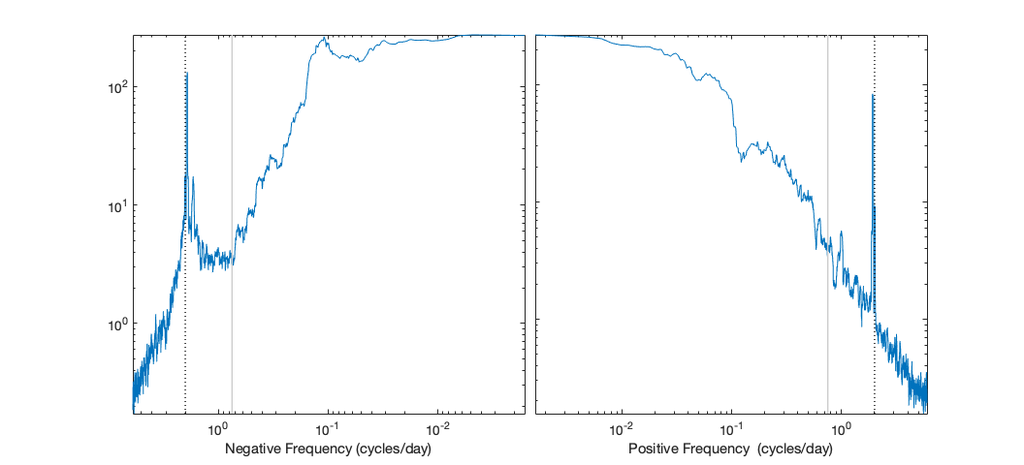

```matlab
% Test 001

load m1244
use m1244
dt=num(2)-num(1);          %Sample rate in days
cv=cv(:,4);cv=cv-mean(cv);
[psio,lambda]=sleptap(length(cv),16);
[f,spp,snn,spn]=mspec(dt,cv,psio,'cyclic');
subplot(1,2,1),plot(f,snn),flipx
xlabel('Negative Frequency (cycles/day)')
subplot(1,2,2),plot(f,spp)
xlabel('Positive Frequency  (cycles/day)')
for i=1:2
    subplot(1,2,i)
    xlog,ylog,axis tight,ax=axis;
    vlines(2,'k:'),vlines(max(f)/8,'C')
end
set(gcf,'paperposition',[0 0 11 5 ])
packfig(1,2,'columns') %pack the column subplots together
```